# Práctico Módulo 4: Inferencia Estadística

Author

Gerardo Esteban, Gómez-Santiago

Published

February 7, 2025

## Introducción

El objetivo de este práctico es reforzar los conocimientos y aplicaciones de Inferencia estadística. La base `muestraIcfes.xlsx` es una base que contiene una muestra aleatoria de los resultados de la Prueba Saber 11 para cada uno de los municipios de Cundinamarca en el año 2020.  
Aclaración: (los municipios que cuentan con 100 observaciones son aquellos de los que se obtuvo una muestra, los que tienen menos observaciones son municipios cuya cantidad de estudiantes que presentaron la prueba es menor a 100 por lo tanto tenemos la población total).

## Pasos previos

- Limpieza del ambiente de trabajo
- Definición del directorio de trabajo
- Activación de librerías
- Carga de la base de datos

```r
rm(list = ls())

setwd("E:/Documents/Escritorio/tidyverso/tidyverso/cursoRLunes/RLunes/scripts/bases/taller3/bases")

library(tidyverse)
library(readxl)

base <- read_xlsx(path = "muestraIcfes.xlsx")
```

## Resolución

### Punto 1.

Calcule los intervalos de confianza de la media del puntaje global (varible `PUNT_GLOBAL`) para cada municipio con un nivel de confianza del 95%.

```r
tablaIntervalos <- base %>%
  group_by(ESTU_MCPIO_RESIDE) %>%
  summarise(media = mean(PUNT_GLOBAL, na.rm = T),
            desvio = sd(PUNT_GLOBAL, na.rm = T),
            n = n()) %>%
  mutate(quantil95 = qt(p = 0.975, df = n-1),
         errorEstandar = desvio/sqrt(n),
         margen = quantil95*errorEstandar,
         Li = media - margen,
         Ls = media + margen
         )

writexl::write_xlsx(x = tablaIntervalos, path = "tablaIntervalosIcfes.xlsx")
```

### Punto 2.

Debido a que son muchos municipios el gráfico de los intervalos de confianza resulta incomodo, intenta hacerlo, pero sino, grafica solamente los intervalos de confianza de los 10 municipios con mayor y de los 10 municipios con menor puntaje.

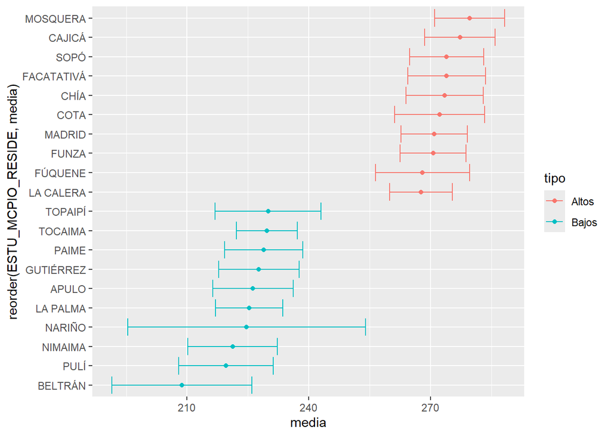

```r
tablaIntervalosGrafico <- tablaIntervalos %>%
  arrange(-media) %>%
  mutate(ind = 1:nrow(tablaIntervalos)) %>%
  filter(ind %in% c(1:10, (nrow(tablaIntervalos)-9):nrow(tablaIntervalos)))

tablaIntervalosGrafico$tipo <- ifelse(test = tablaIntervalosGrafico$ind > 10,
                                      yes = "Bajos",
                                      no = "Altos")

tablaIntervalosGrafico %>%
  ggplot(mapping = aes(x = media, y = reorder(ESTU_MCPIO_RESIDE, media),
                       color = tipo)) +
  geom_point() +
  geom_errorbar(mapping = aes(xmin = Li, xmax = Ls))
```

### Punto 3.

La variable `ESTU_GENERO` dicotomiza a los estudiantes en hombres y mujeres, realice una prueba de hipótesis de diferencia de medias para verificar si existen diferencias significativas el puntaje global.

#### Opción 1: `t.test()`

El comando `t.test()` realiza la prueba de diferencia de medias entre dos categorías, en este caso entre hombres y mujeres.  
Las especificaciones por defecto son:

- $Hipotesis \hspace{0.1cm} Nula \hspace{0.1cm} (H_0): \bar{X_1} - \bar{X_2} = 0$
- $Hipotesis \hspace{0.1cm} Alternativa \hspace{0.1cm} (H_1): \bar{X_1} - \bar{X_2} \neq 0$
- Nivel de confianza $95\%$

```r
t.test(base$PUNT_GLOBAL ~ base$ESTU_GENERO)
```

```
    Welch Two Sample t-test

data:  base$PUNT_GLOBAL by base$ESTU_GENERO
t = -7.4483, df = 8468.3, p-value = 1.038e-13
alternative hypothesis: true difference in means between group F and group M is not equal to 0
95 percent confidence interval:
 -8.562626 -4.994643
sample estimates:
mean in group F mean in group M
       246.5056        253.2843
```

#### Opción 2: `lm()`

Otra manera de realizar una prueba de diferencia de medias es corriendo una regresión lineal con la variable cuantitativa como variable dependiente y la variable categórica como variable independiente. La significatividad del coeficiente indica que la diferencia es significativa, y el valor del coeficiente la variación que ocurriria en promedio si se pasa de una categoría a otra.

```r
reg <- lm(formula = base$PUNT_GLOBAL ~ base$ESTU_GENERO)

summary(reg)
```

```
Call:
lm(formula = base$PUNT_GLOBAL ~ base$ESTU_GENERO)

Residuals:
     Min       1Q   Median       3Q      Max
-253.284  -31.506   -1.284   29.494  188.716

Coefficients:
                  Estimate Std. Error t value Pr(>|t|)
(Intercept)       246.5056     0.5999 410.917  < 2e-16 ***
base$ESTU_GENEROM   6.7786     0.9046   7.493 7.35e-14 ***
---
Signif. codes:  0 '***' 0.001 '**' 0.01 '*' 0.05 '.' 0.1 ' ' 1

Residual standard error: 43.05 on 9190 degrees of freedom
Multiple R-squared:  0.006072,  Adjusted R-squared:  0.005964
F-statistic: 56.15 on 1 and 9190 DF,  p-value: 7.348e-14
```

### Punto 4.

La variable `FAMI_ESTRATOVIVIENDA` nos informa sobre las condiciones socioeconomicas del hogar, a mayor estrato en general, mayores ingresos. Realice una prueba ANOVA para verificar si existen diferencias significativas en el Puntaje Global, tomando como categoria de referencia “Sin Estrato”.

```r
# Verificación de valores unicos

unique(base$FAMI_ESTRATOVIVIENDA)
```

```
[1] "Estrato 2"   "Estrato 1"   "Estrato 3"   "Sin Estrato" "Estrato 4"
[6] NA            "Estrato 5"   "Estrato 6"
```

```r
# Filtro de NA

base <- base %>%
  filter(!is.na(FAMI_ESTRATOVIVIENDA))

# Creción de vector con orden deseado para variable factor

vector <- unique(base$FAMI_ESTRATOVIVIENDA)
vector <- sort(vector)
vector <- c(vector[7], vector[1:6])

# Variable factor

base$FAMI_ESTRATOVIVIENDA <- factor(x = base$FAMI_ESTRATOVIVIENDA,
                                    levels = vector)


summary(base$FAMI_ESTRATOVIVIENDA)
```

```
Sin Estrato   Estrato 1   Estrato 2   Estrato 3   Estrato 4   Estrato 5
        198        2614        4304        1586         207          37
  Estrato 6
         21
```

```r
# Prueba ANOVA

anova <- lm(formula = base$PUNT_GLOBAL ~ base$FAMI_ESTRATOVIVIENDA)

summary(anova)
```

```
Call:
lm(formula = base$PUNT_GLOBAL ~ base$FAMI_ESTRATOVIVIENDA)

Residuals:
     Min       1Q   Median       3Q      Max
-128.758  -31.538   -1.037   28.963  180.242

Coefficients:
                                   Estimate Std. Error t value Pr(>|t|)
(Intercept)                         230.056      2.997  76.758  < 2e-16 ***
base$FAMI_ESTRATOVIVIENDAEstrato 1    9.483      3.109   3.050  0.00229 **
base$FAMI_ESTRATOVIVIENDAEstrato 2   21.981      3.065   7.171 8.03e-13 ***
base$FAMI_ESTRATOVIVIENDAEstrato 3   31.702      3.179   9.973  < 2e-16 ***
base$FAMI_ESTRATOVIVIENDAEstrato 4   31.220      4.192   7.447 1.04e-13 ***
base$FAMI_ESTRATOVIVIENDAEstrato 5   17.701      7.553   2.343  0.01913 *
base$FAMI_ESTRATOVIVIENDAEstrato 6    5.897      9.679   0.609  0.54237
---
Signif. codes:  0 '***' 0.001 '**' 0.01 '*' 0.05 '.' 0.1 ' ' 1

Residual standard error: 42.17 on 8960 degrees of freedom
Multiple R-squared:  0.03816,   Adjusted R-squared:  0.03751
F-statistic: 59.24 on 6 and 8960 DF,  p-value: < 2.2e-16
```

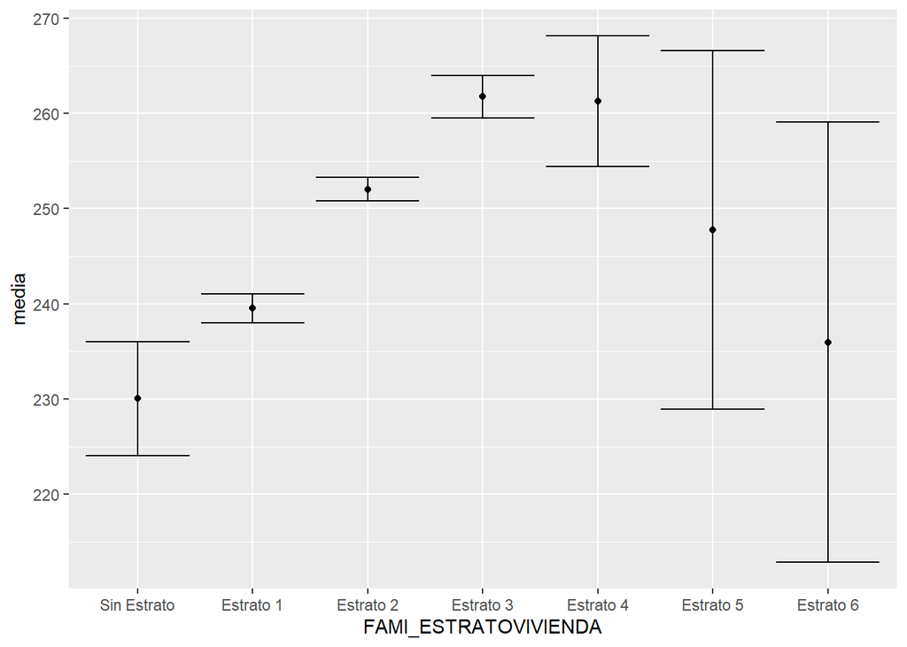

```r
# Grafico de intervalos de confianza por Estrato

tabla_estratos <- base %>%
  group_by(FAMI_ESTRATOVIVIENDA) %>%
  summarise(media = mean(PUNT_GLOBAL, na.rm = T),
            desvio = sd(PUNT_GLOBAL, na.rm = T),
            n = n()) %>%
  mutate(quantil95 = qt(p = 0.975, df = n-1),
         errorEstandar = desvio/sqrt(n),
         margen = quantil95*errorEstandar,
         Li = media - margen,
         Ls = media + margen
         )


tabla_estratos %>%
  ggplot(mapping = aes(x = FAMI_ESTRATOVIVIENDA, y = media)) +
  geom_point() +
  geom_errorbar(mapping = aes(ymin = Li, ymax = Ls))
```

### Punto 5.

Pregunta Teórica: ¿porque no tiene sentido calcular los intervalos de confianza en los municipios con menos de 100 observaciones?

Debido a que contamos con la población de examenes en municipios con menos de 100 observaciones, no tiene sentido hacer inferencia estadística en estos municipios, pues el estimador puntual se corresponde con el parametro poblacional.